# Supervised Learning Project

## Part 1. Project based

DOMAIN: Healthcare  
CONTEXT: Medical research university X is undergoing a deep research on patients with certain conditions.University has an internal AI team. Due to con identiality the patient’s details and the conditions are masked by the client by providing different datasets to the AI team for developing a AIML model which can predict the condition of the patient depending on the received test results.  
DATA DESCRIPTION: The data consists of biomechanics features of the patients according to their current conditions. Each patient is represented in the data set by six biomechanics attributes derived from the shape and orientation of the condition to their body part.

1. P_incidence
2. P_tilt
3. L_angle
4. S_slope
5. P_radius
6. S_degree
7. Clas

### Import all the necessary libraries

```python
import numpy as np
import scipy.stats as stats
import matplotlib.pyplot as plt
import pandas as pd
import seaborn as sns
%matplotlib inline
import warnings
warnings.filterwarnings('ignore')
```

### Importing ML models from Scikit learn

```python
from sklearn.preprocessing import LabelEncoder
from sklearn.model_selection import train_test_split
from sklearn.metrics import precision_recall_fscore_support, mean_absolute_error
from sklearn.metrics import accuracy_score, confusion_matrix, classification_report
from sklearn.preprocessing import StandardScaler
from sklearn.linear_model import LogisticRegression
from sklearn.naive_bayes import GaussianNB
from sklearn.naive_bayes import BernoulliNB
from sklearn.neighbors import KNeighborsClassifier
from sklearn.svm import SVC
```

## Data import and Warehouse

```python
from google.colab import drive
drive.mount('/content/drive')
```

```python
# Reading the Normal data data and getting first five rows for viewing
Normal_raw = pd.read_csv('/content/drive/MyDrive/AI_ML course/Part1+-+Normal.csv')
Normal_raw.head()
```

|  | P_incidence | P_tilt | L_angle | S_slope | P_radius | S_Degree | Class |
| --- | --- | --- | --- | --- | --- | --- | --- |
| 0 | 38.505273 | 16.964297 | 35.112814 | 21.540976 | 127.632875 | 7.986683 | Normal |
| 1 | 54.920858 | 18.968430 | 51.601455 | 35.952428 | 125.846646 | 2.001642 | Normal |
| 2 | 44.362490 | 8.945435 | 46.902096 | 35.417055 | 129.220682 | 4.994195 | Normal |
| 3 | 48.318931 | 17.452121 | 48.000000 | 30.866809 | 128.980308 | -0.910941 | Normal |
| 4 | 45.701789 | 10.659859 | 42.577846 | 35.041929 | 130.178314 | -3.388910 | Normal |

```python
# Printing the shape of the data
Normal_raw.shape
```

```
(100, 7)
```

```python
# Reading the Type H data data and getting first five rows for viewing
TypeH_raw = pd.read_csv('/content/drive/MyDrive/AI_ML course/Part1+-+Type_H.csv')
TypeH_raw.head()
```

|  | P_incidence | P_tilt | L_angle | S_slope | P_radius | S_Degree | Class |
| --- | --- | --- | --- | --- | --- | --- | --- |
| 0 | 63.027817 | 22.552586 | 39.609117 | 40.475232 | 98.672917 | -0.254400 | Type_H |
| 1 | 39.056951 | 10.060991 | 25.015378 | 28.995960 | 114.405425 | 4.564259 | Type_H |
| 2 | 68.832021 | 22.218482 | 50.092194 | 46.613539 | 105.985135 | -3.530317 | Type_H |
| 3 | 69.297008 | 24.652878 | 44.311238 | 44.644130 | 101.868495 | 11.211523 | Type_H |
| 4 | 49.712859 | 9.652075 | 28.317406 | 40.060784 | 108.168725 | 7.918501 | Type_H |

```python
TypeH_raw.shape
```

```
(60, 7)
```

```python
# Reading the Type S data data and getting first five rows for viewing
TypeS_raw = pd.read_csv('/content/drive/MyDrive/AI_ML course/Part1+-+Type_S.csv')
TypeS_raw.head()
```

|  | P_incidence | P_tilt | L_angle | S_slope | P_radius | S_Degree | Class |
| --- | --- | --- | --- | --- | --- | --- | --- |
| 0 | 74.377678 | 32.053104 | 78.772013 | 42.324573 | 143.560690 | 56.125906 | Type_S |
| 1 | 89.680567 | 32.704435 | 83.130732 | 56.976132 | 129.955476 | 92.027277 | Type_S |
| 2 | 44.529051 | 9.433234 | 52.000000 | 35.095817 | 134.711772 | 29.106575 | Type_S |
| 3 | 77.690577 | 21.380645 | 64.429442 | 56.309932 | 114.818751 | 26.931841 | Type_S |
| 4 | 76.147212 | 21.936186 | 82.961502 | 54.211027 | 123.932010 | 10.431972 | Type_S |

```python
TypeS_raw.shape
```

```
(150, 7)
```

```python
## Concatenate all the three dataframes to one
frames = [Normal_raw,TypeH_raw,TypeS_raw]
Total_raw = pd.concat(frames)
Total_raw.head()
```

|  | P_incidence | P_tilt | L_angle | S_slope | P_radius | S_Degree | Class |
| --- | --- | --- | --- | --- | --- | --- | --- |
| 0 | 38.505273 | 16.964297 | 35.112814 | 21.540976 | 127.632875 | 7.986683 | Normal |
| 1 | 54.920858 | 18.968430 | 51.601455 | 35.952428 | 125.846646 | 2.001642 | Normal |
| 2 | 44.362490 | 8.945435 | 46.902096 | 35.417055 | 129.220682 | 4.994195 | Normal |
| 3 | 48.318931 | 17.452121 | 48.000000 | 30.866809 | 128.980308 | -0.910941 | Normal |
| 4 | 45.701789 | 10.659859 | 42.577846 | 35.041929 | 130.178314 | -3.388910 | Normal |

```python
# Shape of the Total data
Total_raw.shape
```

```
(310, 7)
```

## Data cleaning

```python
# Checking data types for each attributes in data
Total_raw.dtypes
```

```
P_incidence    float64
P_tilt         float64
L_angle        float64
S_slope        float64
P_radius       float64
S_Degree       float64
Class           object
dtype: object
```

```python
# Print unique categories in Data
print(Total_raw["Class"].unique())
```

```
['Normal' 'Nrmal' 'Type_H' 'type_h' 'Type_S' 'tp_s']
```

```python
# Print unique categories in original data
print(Normal_raw["Class"].unique())
print(TypeH_raw["Class"].unique())
print(TypeS_raw["Class"].unique())
```

```
['Normal' 'Nrmal']
['Type_H' 'type_h']
['Type_S' 'tp_s']
```

```python
# Replace Nrmal with Normal, type_h with Type_H and tp_s as Type_S
Total_raw["Class"].replace(to_replace ="Nrmal",value ="Normal", inplace=True);
Total_raw["Class"].replace(to_replace ="type_h",value ="Type_H", inplace=True);
Total_raw["Class"].replace(to_replace ="tp_s",value ="Type_S", inplace=True);
# Print unique categories in Data
print(Total_raw["Class"].unique())
```

```
['Normal' 'Type_H' 'Type_S']
```

```python
Total_raw["Class"].value_counts()
```

```
Type_S    150
Normal    100
Type_H     60
Name: Class, dtype: int64
```

```python
# Convert Class column to Categorical data type
Total_raw.Class = Total_raw["Class"].astype('category')
Total_raw.dtypes
```

```
P_incidence     float64
P_tilt          float64
L_angle         float64
S_slope         float64
P_radius        float64
S_Degree        float64
Class          category
dtype: object
```

```python
# Checking the dataset for standard null value
Total_raw.isnull().values.any()
Total_raw.isnull().values.sum().sum()
```

```
0
```

## Exploratory Data analysis

```python
Total_raw.info()
Total_raw = Total_raw[~Total_raw.index.duplicated()]
#df = df[~df.index.duplicated()]
```

```
<class 'pandas.core.frame.DataFrame'>
Int64Index: 310 entries, 0 to 149
Data columns (total 7 columns):
 #   Column       Non-Null Count  Dtype
---  ------       --------------  -----
 0   P_incidence  310 non-null    float64
 1   P_tilt       310 non-null    float64
 2   L_angle      310 non-null    float64
 3   S_slope      310 non-null    float64
 4   P_radius     310 non-null    float64
 5   S_Degree     310 non-null    float64
 6   Class        310 non-null    category
dtypes: category(1), float64(6)
memory usage: 17.4 KB
```

```python
Total_raw.describe().T
```

|  | count | mean | std | min | 25% | 50% | 75% | max |
| --- | --- | --- | --- | --- | --- | --- | --- | --- |
| P_incidence | 150.0 | 58.533465 | 16.845401 | 30.741938 | 45.607059 | 55.527372 | 68.492606 | 118.144655 |
| P_tilt | 150.0 | 15.711106 | 9.862900 | -5.845994 | 9.326520 | 14.192100 | 19.897562 | 49.431864 |
| L_angle | 150.0 | 51.669165 | 18.763156 | 19.071075 | 37.000000 | 48.050000 | 61.555889 | 125.742385 |
| S_slope | 150.0 | 42.822359 | 12.246781 | 17.386972 | 33.440151 | 42.010752 | 50.554251 | 79.695154 |
| P_radius | 150.0 | 119.379292 | 14.331022 | 70.082575 | 113.785415 | 120.990236 | 128.241054 | 157.848799 |
| S_Degree | 150.0 | 18.061306 | 27.612699 | -11.058179 | -0.210845 | 4.977270 | 30.946022 | 124.984406 |

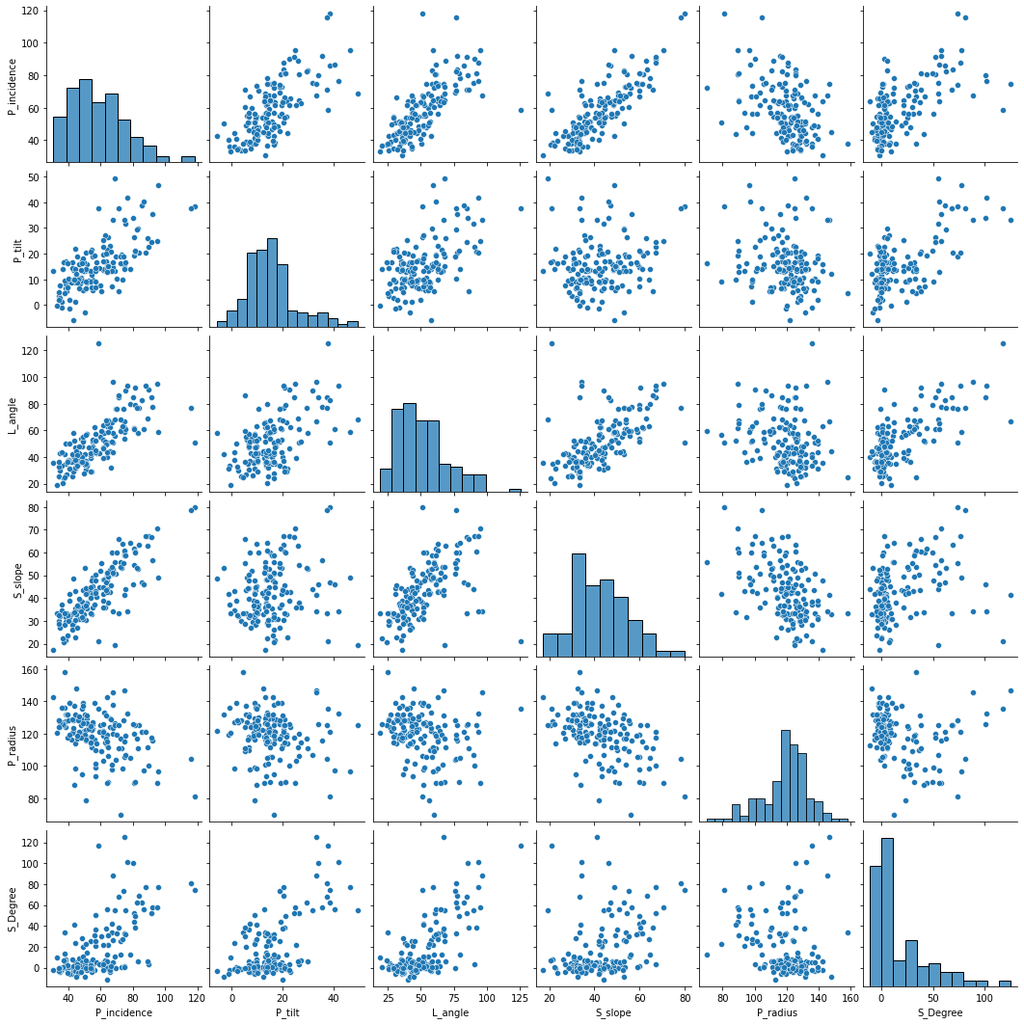

```python
# Checking Univariate and Bivariate distribution for all the variables
sns.pairplot(Total_raw)
```

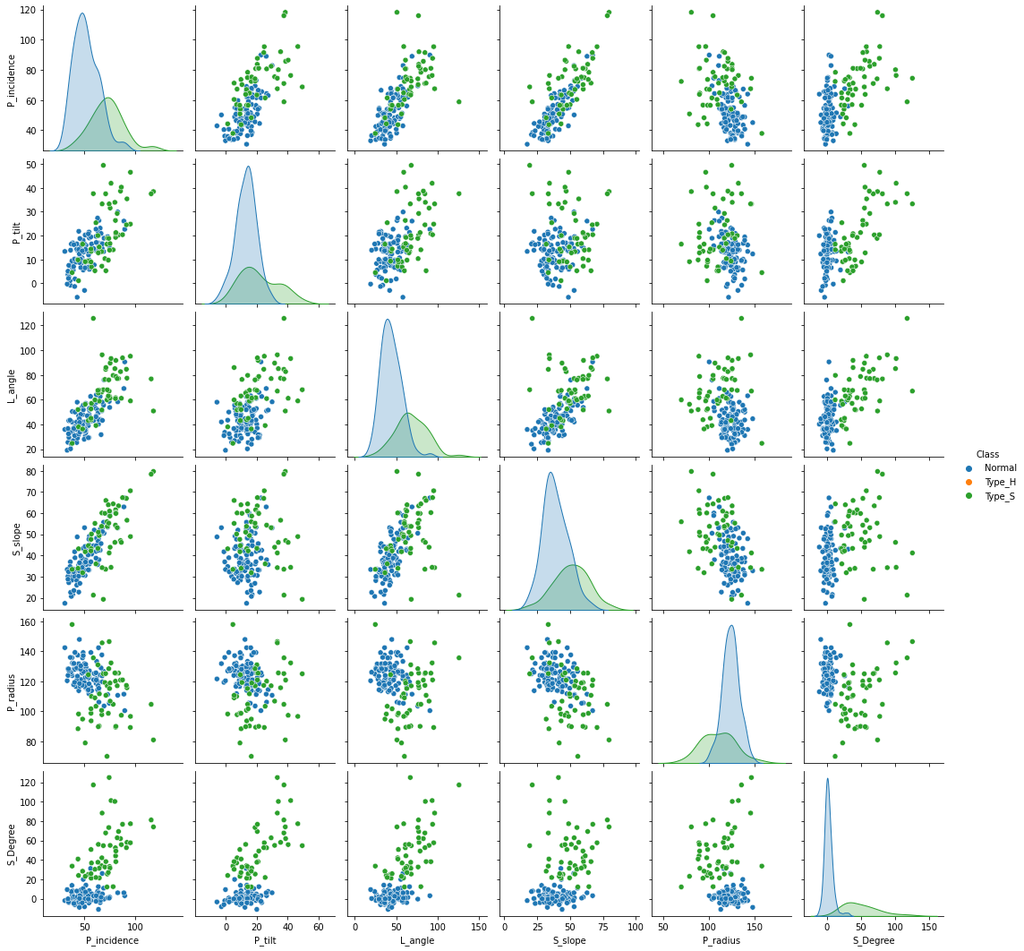

```python
# Checking class distribition over univariate and Bivariate plots
sns.pairplot(Total_raw, hue='Class')
```

```python
# Coorelation table for all variables
Total_raw.corr()
```

|  | P_incidence | P_tilt | L_angle | S_slope | P_radius | S_Degree |
| --- | --- | --- | --- | --- | --- | --- |
| P_incidence | 1.000000 | 0.695361 | 0.723970 | 0.815490 | -0.441438 | 0.621751 |
| P_tilt | 0.695361 | 1.000000 | 0.540983 | 0.151120 | -0.160357 | 0.629271 |
| L_angle | 0.723970 | 0.540983 | 1.000000 | 0.560139 | -0.208430 | 0.712781 |
| S_slope | 0.815490 | 0.151120 | 0.560139 | 1.000000 | -0.478053 | 0.348434 |
| P_radius | -0.441438 | -0.160357 | -0.208430 | -0.478053 | 1.000000 | -0.185792 |
| S_Degree | 0.621751 | 0.629271 | 0.712781 | 0.348434 | -0.185792 | 1.000000 |

```python
Total_raw.var()
```

```
P_incidence    283.767544
P_tilt          97.276789
L_angle        352.056024
S_slope        149.983650
P_radius       205.378194
S_Degree       762.461158
dtype: float64
```

## Data preprocessing

```python
# Check class balance in the data
Total_raw["Class"].value_counts()
```

```
Normal    100
Type_S     50
Type_H      0
Name: Class, dtype: int64
```

```python
from sklearn.preprocessing import LabelEncoder
class_label_encoder = LabelEncoder()

#Total_raw["Class"] = class_label_encoder.fit_transform(Total_raw["Class"])
```

```python
import numpy as np
from sklearn.model_selection import train_test_split
from scipy.stats import zscore

# Transform data into features and target
X_org = Total_raw.drop(['Class'], axis=1)
y = Total_raw['Class']
```

```python
# convert the features into z scores as we do not know what units / scales were used and store them in new dataframe

X  = X_org.apply(zscore)  # convert all attributes to Z scale
#X = (X - np.min(X))/(np.max(X)-np.min(X))

X.describe()
```

|  | P_incidence | P_tilt | L_angle | S_slope | P_radius | S_Degree |
| --- | --- | --- | --- | --- | --- | --- |
| count | 1.500000e+02 | 1.500000e+02 | 1.500000e+02 | 1.500000e+02 | 1.500000e+02 | 1.500000e+02 |
| mean | -1.421085e-16 | -1.184238e-16 | 3.789561e-16 | 4.736952e-17 | -1.468455e-15 | -9.473903e-17 |
| std | 1.003350e+00 | 1.003350e+00 | 1.003350e+00 | 1.003350e+00 | 1.003350e+00 | 1.003350e+00 |
| min | -1.655326e+00 | -2.192998e+00 | -1.743166e+00 | -2.083862e+00 | -3.451384e+00 | -1.058101e+00 |
| 25% | -7.699259e-01 | -6.495022e-01 | -7.844260e-01 | -7.686623e-01 | -3.916411e-01 | -6.639468e-01 |
| 50% | -1.790497e-01 | -1.545281e-01 | -1.935330e-01 | -6.649305e-02 | 1.127861e-01 | -4.754287e-01 |
| 75% | 5.931889e-01 | 4.258870e-01 | 5.286875e-01 | 6.334558e-01 | 6.204338e-01 | 4.681861e-01 |
| max | 3.550577e+00 | 3.430403e+00 | 3.961027e+00 | 3.020902e+00 | 2.693345e+00 | 3.885216e+00 |

```python
# split into train and test
X_train, X_test, y_train, y_test = train_test_split(X, y, test_size=0.2, random_state=7)
```

```python
print(X_train.shape)
print(y_train.shape)
```

```
(120, 6)
(120,)
```

```python
print(X_test.shape)
print(y_test.shape)
```

```
(30, 6)
(30,)
```

```python
# loading library
from sklearn.neighbors import KNeighborsClassifier
from sklearn.metrics import accuracy_score

# instantiate learning model (k = 3)
knn = KNeighborsClassifier(n_neighbors = 3)

# fitting the model
knn.fit(X_train, y_train)

# predict the response
y_pred = knn.predict(X_test)

# evaluate accuracy
print(accuracy_score(y_test, y_pred))

# instantiate learning model (k = 5)
knn = KNeighborsClassifier(n_neighbors=5)

# fitting the model
knn.fit(X_train, y_train)

# predict the response
y_pred = knn.predict(X_test)

# evaluate accuracy
print(accuracy_score(y_test, y_pred))

# instantiate learning model (k = 9)
knn = KNeighborsClassifier(n_neighbors=9)

# fitting the model
knn.fit(X_train, y_train)

# predict the response
y_pred = knn.predict(X_test)

# evaluate accuracy
print(accuracy_score(y_test, y_pred))
```

```
0.9333333333333333
0.9333333333333333
0.9
```

```python
# creating odd list of K for KNN
myList = list(range(1,30))

# subsetting just the odd ones
neighbors = list(filter(lambda x: x % 2 != 0, myList))
```

```python
# empty list that will hold accuracy scores
ac_scores = []

# perform accuracy metrics for values from 1,3,5....19
for k in neighbors:
    knn = KNeighborsClassifier(n_neighbors=k,metric='minkowski')
    knn.fit(X_train, y_train)
    # predict the response
    y_pred = knn.predict(X_test)
    # evaluate accuracy
    scores = accuracy_score(y_test, y_pred)
    ac_scores.append(scores)

# changing to misclassification error
MSE = [1 - x for x in ac_scores]

# determining best k
optimal_k = neighbors[MSE.index(min(MSE))]
print("The optimal number of neighbors is %d" % optimal_k)
```

```
The optimal number of neighbors is 1
```

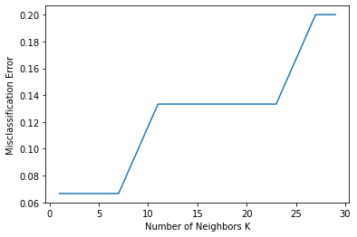

```python
import matplotlib.pyplot as plt
# plot misclassification error vs k
plt.plot(neighbors, MSE)
plt.xlabel('Number of Neighbors K')
plt.ylabel('Misclassification Error')
plt.show()
```

```python
# instantiate learning model (k = 9)
knn = KNeighborsClassifier(n_neighbors=15,weights = 'distance')

# fitting the model
knn.fit(X_train, y_train)

# predict the response
y_pred = knn.predict(X_test)

# evaluate accuracy
print(accuracy_score(y_test, y_pred))
```

```
0.8666666666666667
```

```python
# instantiate learning model (k = 9)
knn = KNeighborsClassifier(n_neighbors=15,metric = 'minkowski')

# fitting the model
knn.fit(X_train, y_train)

# predict the response
y_pred = knn.predict(X_test)

# evaluate accuracy
print(accuracy_score(y_test, y_pred))
```

```
0.8666666666666667
```

## Part 2. Project based

• DOMAIN: Banking and inance  
• CONTEXT: A bank X is on a massive digital transformation for all its departments. Bank has a growing customer base whee majority of them are liability customers (depositors) vs borrowers (asset customers). The bank is interested in expanding the borrowers base rapidly to bring in more business via loan interests. A campaign that the bank ran in last quarter showed an average single digit conversion rate. Digital transformation being the core strength of the business strategy, marketing department wants to devise effective campaigns with better target marketing to increase the conversion ratio to double digit with same budget as per last campaign.  
• DATA DESCRIPTION: The data consists of the following attributes:

1. ID: Customer ID
2. Age Customer’s approximate age.
3. CustomerSince: Customer of the bank since. [unit is masked]
4. HighestSpend: Customer’s highest spend so far in one transaction. [unit is masked]
5. ZipCode: Customer’s zip code.
6. HiddenScore: A score associated to the customer which is masked by the bank as an IP.
7. MonthlyAverageSpend: Customer’s monthly average spend so far. [unit is masked]
8. Level: A level associated to the customer which is masked by the bank as an IP.
9. Mortgage: Customer’s mortgage. [unit is masked]
10. Security: Customer’s security asset with the bank. [unit is masked]
11. FixedDepositAccount: Customer’s ixed deposit account with the bank. [unit is masked]
12. InternetBanking: if the customer uses internet banking.
13. CreditCard: if the customer uses bank’s credit card.
14. LoanOnCard: if the customer has a loan on credit card

### PROJECT OBJECTIVE:

Build an AIML model to perform focused marketing by predicting the potential customers who will convert using the historical datase.

### 1. Import and warehouse data:

• Import all the given datasets and explore shape and size of each. • Merge all datasets onto one and explore inal shape and size.

```python
# Reading the Normal data data and getting first five rows for viewing
Cust_raw = pd.read_csv('/content/drive/MyDrive/AI_ML course/Part2+-+Data1.csv')
Cust_raw.head()
```

|  | ID | Age | CustomerSince | HighestSpend | ZipCode | HiddenScore | MonthlyAverageSpend | Level |
| --- | --- | --- | --- | --- | --- | --- | --- | --- |
| 0 | 1 | 25 | 1 | 49 | 91107 | 4 | 1.6 | 1 |
| 1 | 2 | 45 | 19 | 34 | 90089 | 3 | 1.5 | 1 |
| 2 | 3 | 39 | 15 | 11 | 94720 | 1 | 1.0 | 1 |
| 3 | 4 | 35 | 9 | 100 | 94112 | 1 | 2.7 | 2 |
| 4 | 5 | 35 | 8 | 45 | 91330 | 4 | 1.0 | 2 |

```python
# Printing the shape of the data
Cust_raw.shape
```

```
(5000, 8)
```

```python
Account_raw = pd.read_csv('/content/drive/MyDrive/AI_ML course/Part2+-Data2.csv')
Account_raw.head()
```

|  | ID | Mortgage | Security | FixedDepositAccount | InternetBanking | CreditCard | LoanOnCard |
| --- | --- | --- | --- | --- | --- | --- | --- |
| 0 | 1 | 0 | 1 | 0 | 0 | 0 | NaN |
| 1 | 2 | 0 | 1 | 0 | 0 | 0 | NaN |
| 2 | 3 | 0 | 0 | 0 | 0 | 0 | NaN |
| 3 | 4 | 0 | 0 | 0 | 0 | 0 | NaN |
| 4 | 5 | 0 | 0 | 0 | 0 | 1 | NaN |

```python
# Printing the shape of the data
Account_raw.shape
```

```
(5000, 7)
```

```python
## Concatenate two dataframes to one
frames = [Cust_raw,Account_raw.drop(['ID'], axis=1)]
Loan_raw = pd.concat(frames, axis=1, verify_integrity=True)
Loan_raw.head()
```

|  | ID | Age | CustomerSince | HighestSpend | ZipCode | HiddenScore | MonthlyAverageSpend | Level | Mortgage | Security | FixedDepositAccount | InternetBanking | CreditCard | LoanOnCard |
| --- | --- | --- | --- | --- | --- | --- | --- | --- | --- | --- | --- | --- | --- | --- |
| 0 | 1 | 25 | 1 | 49 | 91107 | 4 | 1.6 | 1 | 0 | 1 | 0 | 0 | 0 | NaN |
| 1 | 2 | 45 | 19 | 34 | 90089 | 3 | 1.5 | 1 | 0 | 1 | 0 | 0 | 0 | NaN |
| 2 | 3 | 39 | 15 | 11 | 94720 | 1 | 1.0 | 1 | 0 | 0 | 0 | 0 | 0 | NaN |
| 3 | 4 | 35 | 9 | 100 | 94112 | 1 | 2.7 | 2 | 0 | 0 | 0 | 0 | 0 | NaN |
| 4 | 5 | 35 | 8 | 45 | 91330 | 4 | 1.0 | 2 | 0 | 0 | 0 | 0 | 1 | NaN |

```python
# Printing the shape of the data
Loan_raw.shape
```

```
(5000, 14)
```

### 2. Data cleansing:

• Explore and if required correct the datatypes of each attribute • Explore for null values in the attributes and if required drop or impute values

```python
# Get info of the dataframe columns
Loan_raw.info()
```

```
<class 'pandas.core.frame.DataFrame'>
RangeIndex: 5000 entries, 0 to 4999
Data columns (total 14 columns):
 #   Column               Non-Null Count  Dtype
---  ------               --------------  -----
 0   ID                   5000 non-null   int64
 1   Age                  5000 non-null   int64
 2   CustomerSince        5000 non-null   int64
 3   HighestSpend         5000 non-null   int64
 4   ZipCode              5000 non-null   int64
 5   HiddenScore          5000 non-null   int64
 6   MonthlyAverageSpend  5000 non-null   float64
 7   Level                5000 non-null   int64
 8   Mortgage             5000 non-null   int64
 9   Security             5000 non-null   int64
 10  FixedDepositAccount  5000 non-null   int64
 11  InternetBanking      5000 non-null   int64
 12  CreditCard           5000 non-null   int64
 13  LoanOnCard           4980 non-null   float64
dtypes: float64(2), int64(12)
memory usage: 547.0 KB
```

```python
# Checking the dataset for null value
Loan_raw.isnull().sum()
```

```
ID                      0
Age                     0
CustomerSince           0
HighestSpend            0
ZipCode                 0
HiddenScore             0
MonthlyAverageSpend     0
Level                   0
Mortgage                0
Security                0
FixedDepositAccount     0
InternetBanking         0
CreditCard              0
LoanOnCard             20
dtype: int64
```

#### Observation

Loan on Card data has only 4980 count so data need to be checked for NAN values. If present, they will be replaced by 0 values . (No loan cases)

```python
Loan_raw["LoanOnCard"] = Loan_raw["LoanOnCard"].fillna(0)
```

```python
# Check distribution for target values in the data
Loan_raw["LoanOnCard"].value_counts()
```

```
0.0    4520
1.0     480
Name: LoanOnCard, dtype: int64
```

#### Observation on Distribution of target variable

Among 5,000 customers, only 480 (=9.6%) accepted the card loan that was offered to them in the earlier campaign.

```python
# Getting description of the data
Loan_raw.describe().T
```

|  | count | mean | std | min | 25% | 50% | 75% | max |
| --- | --- | --- | --- | --- | --- | --- | --- | --- |
| ID | 5000.0 | 2500.500000 | 1443.520003 | 1.0 | 1250.75 | 2500.5 | 3750.25 | 5000.0 |
| Age | 5000.0 | 45.338400 | 11.463166 | 23.0 | 35.00 | 45.0 | 55.00 | 67.0 |
| CustomerSince | 5000.0 | 20.104600 | 11.467954 | -3.0 | 10.00 | 20.0 | 30.00 | 43.0 |
| HighestSpend | 5000.0 | 73.774200 | 46.033729 | 8.0 | 39.00 | 64.0 | 98.00 | 224.0 |
| ZipCode | 5000.0 | 93152.503000 | 2121.852197 | 9307.0 | 91911.00 | 93437.0 | 94608.00 | 96651.0 |
| HiddenScore | 5000.0 | 2.396400 | 1.147663 | 1.0 | 1.00 | 2.0 | 3.00 | 4.0 |
| MonthlyAverageSpend | 5000.0 | 1.937938 | 1.747659 | 0.0 | 0.70 | 1.5 | 2.50 | 10.0 |
| Level | 5000.0 | 1.881000 | 0.839869 | 1.0 | 1.00 | 2.0 | 3.00 | 3.0 |
| Mortgage | 5000.0 | 56.498800 | 101.713802 | 0.0 | 0.00 | 0.0 | 101.00 | 635.0 |
| Security | 5000.0 | 0.104400 | 0.305809 | 0.0 | 0.00 | 0.0 | 0.00 | 1.0 |
| FixedDepositAccount | 5000.0 | 0.060400 | 0.238250 | 0.0 | 0.00 | 0.0 | 0.00 | 1.0 |
| InternetBanking | 5000.0 | 0.596800 | 0.490589 | 0.0 | 0.00 | 1.0 | 1.00 | 1.0 |
| CreditCard | 5000.0 | 0.294000 | 0.455637 | 0.0 | 0.00 | 0.0 | 1.00 | 1.0 |
| LoanOnCard | 5000.0 | 0.096000 | 0.294621 | 0.0 | 0.00 | 0.0 | 0.00 | 1.0 |

#### Observations

1. CustomerSince shows a duration of the customer with bank and hence cannot be negative. All the negative values will be replaced by 0
2. ZipCode has minimum value of 9307.0 which has four digits, whereas majorities of values are of 5 digits. This may be due to some mistake. Replacing mistake values with median value.

```python
# Replacing Negative experience values with 0
Loan_raw.loc[(Loan_raw['CustomerSince'] < 0),'CustomerSince'] = 0
Loan_raw.describe().T
```

|  | count | mean | std | min | 25% | 50% | 75% | max |
| --- | --- | --- | --- | --- | --- | --- | --- | --- |
| ID | 5000.0 | 2500.500000 | 1443.520003 | 1.0 | 1250.75 | 2500.5 | 3750.25 | 5000.0 |
| Age | 5000.0 | 45.338400 | 11.463166 | 23.0 | 35.00 | 45.0 | 55.00 | 67.0 |
| CustomerSince | 5000.0 | 20.119600 | 11.440484 | 0.0 | 10.00 | 20.0 | 30.00 | 43.0 |
| HighestSpend | 5000.0 | 73.774200 | 46.033729 | 8.0 | 39.00 | 64.0 | 98.00 | 224.0 |
| ZipCode | 5000.0 | 93152.503000 | 2121.852197 | 9307.0 | 91911.00 | 93437.0 | 94608.00 | 96651.0 |
| HiddenScore | 5000.0 | 2.396400 | 1.147663 | 1.0 | 1.00 | 2.0 | 3.00 | 4.0 |
| MonthlyAverageSpend | 5000.0 | 1.937938 | 1.747659 | 0.0 | 0.70 | 1.5 | 2.50 | 10.0 |
| Level | 5000.0 | 1.881000 | 0.839869 | 1.0 | 1.00 | 2.0 | 3.00 | 3.0 |
| Mortgage | 5000.0 | 56.498800 | 101.713802 | 0.0 | 0.00 | 0.0 | 101.00 | 635.0 |
| Security | 5000.0 | 0.104400 | 0.305809 | 0.0 | 0.00 | 0.0 | 0.00 | 1.0 |
| FixedDepositAccount | 5000.0 | 0.060400 | 0.238250 | 0.0 | 0.00 | 0.0 | 0.00 | 1.0 |
| InternetBanking | 5000.0 | 0.596800 | 0.490589 | 0.0 | 0.00 | 1.0 | 1.00 | 1.0 |
| CreditCard | 5000.0 | 0.294000 | 0.455637 | 0.0 | 0.00 | 0.0 | 1.00 | 1.0 |
| LoanOnCard | 5000.0 | 0.096000 | 0.294621 | 0.0 | 0.00 | 0.0 | 0.00 | 1.0 |

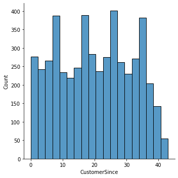

```python
# Checking the values by plotting distribution
sns.displot(Loan_raw['CustomerSince']);
```

```python
# replace incorrect ZIP Code values with median (four digit values with median)
display(Loan_raw[Loan_raw['ZipCode'] < 10000])
Loan_raw.loc[(Loan_raw['ZipCode'] < 10000),'ZipCode'] = 93437
```

|  | ID | Age | CustomerSince | HighestSpend | ZipCode | HiddenScore | MonthlyAverageSpend | Level | Mortgage | Security | FixedDepositAccount | InternetBanking | CreditCard | LoanOnCard |
| --- | --- | --- | --- | --- | --- | --- | --- | --- | --- | --- | --- | --- | --- | --- |
| 384 | 385 | 51 | 25 | 21 | 9307 | 4 | 0.6 | 3 | 0 | 0 | 0 | 1 | 1 | 0.0 |

```python
# Setting correct data type for each attribute of the data
# 1. Numerical attributes: Age, CustomerSince, HighestSpend,HiddenScore, MonthlyAverageSpend,
#                         ,Level, Mortgage
# 2. Catagorical attributes:ID (Nominal values), ZipCode (Nominal values), Security                0
#                           ,FixedDepositAccount, InternetBanking, CreditCard,LoanOnCard

# Convert relevant columns to numerical attribute
numerics_columns = ["Age", "CustomerSince", "HighestSpend", "HiddenScore", "MonthlyAverageSpend", "Level", "Mortgage"]
num_attr = Loan_raw[numerics_columns].apply(pd.to_numeric, errors="coerce")

# Convert relavant columns to categorical data type
catog_columns = ["ID","ZipCode","Security","FixedDepositAccount","InternetBanking","CreditCard","LoanOnCard"]
cat_attr = Loan_raw[catog_columns].apply(pd.Categorical)

Loan_raw = pd.concat([num_attr,cat_attr], axis=1, join="inner")
```

### 3. Data analysis & visualisation:

• Perform detailed statistical analysis on the data. • Perform a detailed univariate, bivariate and multivariate analysis with appropriate detailed comments after each analysis.

```python
# Five point summary of numerical attributes
Loan_raw.describe().T
```

|  | count | mean | std | min | 25% | 50% | 75% | max |
| --- | --- | --- | --- | --- | --- | --- | --- | --- |
| Age | 5000.0 | 45.338400 | 11.463166 | 23.0 | 35.0 | 45.0 | 55.0 | 67.0 |
| CustomerSince | 5000.0 | 20.119600 | 11.440484 | 0.0 | 10.0 | 20.0 | 30.0 | 43.0 |
| HighestSpend | 5000.0 | 73.774200 | 46.033729 | 8.0 | 39.0 | 64.0 | 98.0 | 224.0 |
| HiddenScore | 5000.0 | 2.396400 | 1.147663 | 1.0 | 1.0 | 2.0 | 3.0 | 4.0 |
| MonthlyAverageSpend | 5000.0 | 1.937938 | 1.747659 | 0.0 | 0.7 | 1.5 | 2.5 | 10.0 |
| Level | 5000.0 | 1.881000 | 0.839869 | 1.0 | 1.0 | 2.0 | 3.0 | 3.0 |
| Mortgage | 5000.0 | 56.498800 | 101.713802 | 0.0 | 0.0 | 0.0 | 101.0 | 635.0 |

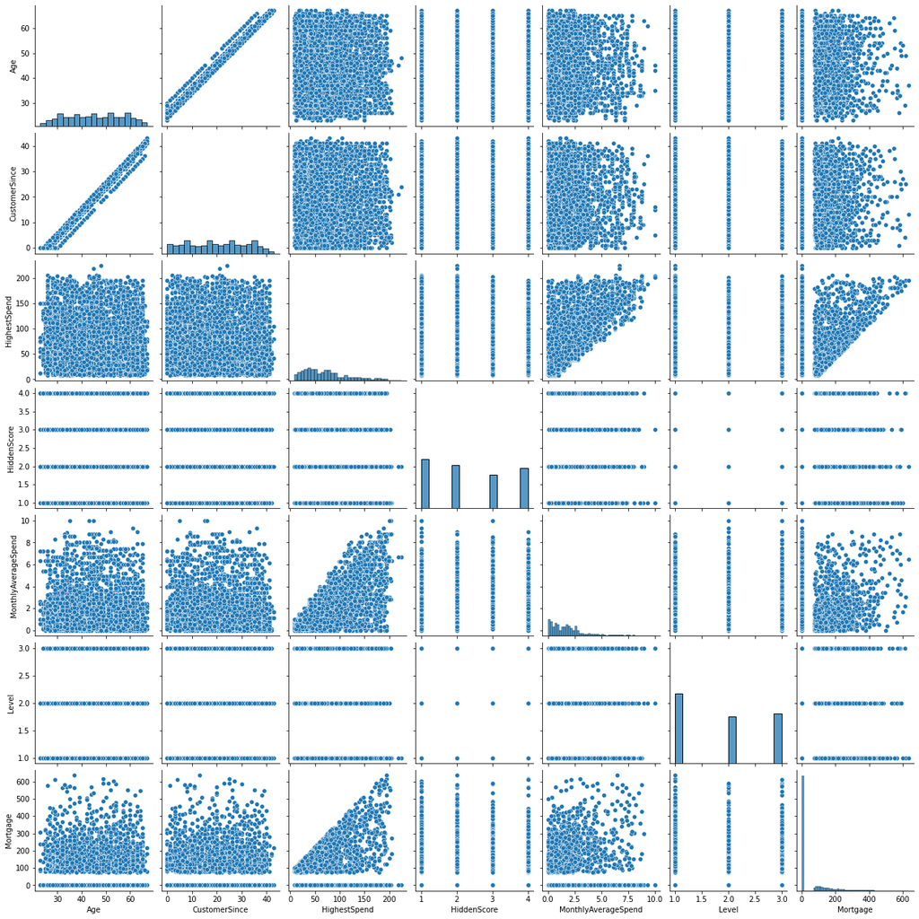

```python
# Plotting pairplot for univariate and Bivariate analysis
sns.pairplot(Loan_raw[numerics_columns]);
```

#### Observation

1. `Age` and `CustomerSince` have strong positive correlation.

```python
# Checking number of unique values for categorical columns
Loan_raw[catog_columns].nunique()
```

```
ID                     5000
ZipCode                 466
Security                  2
FixedDepositAccount       2
InternetBanking           2
CreditCard                2
LoanOnCard                2
dtype: int64
```

#### Removing columns from the further analysis

- Removing columns such as ID that does not add any interesting information. There is no association between a person's customer ID and loan, also it does not provide any general conclusion for future potential loan customers. Neglecting this information for our model prediction.
- Removing ZIP Code from the analysis since it's a nominal variable and contains 466 unique values.

```python
LoanData = Loan_raw.drop(['ID', 'ZipCode'], axis = 1)
LoanData.columns
```

```
Index(['Age', 'CustomerSince', 'HighestSpend', 'HiddenScore',
       'MonthlyAverageSpend', 'Level', 'Mortgage', 'Security',
       'FixedDepositAccount', 'InternetBanking', 'CreditCard', 'LoanOnCard'],
      dtype='object')
```

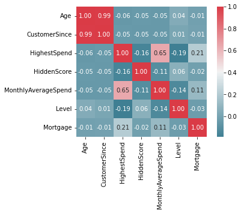

```python
corr = LoanData.drop('LoanOnCard', axis = 1).corr()
cmap = sns.diverging_palette(220, 10, as_cmap = True)
sns.heatmap(corr,cmap=cmap, vmax = 1, square = True, annot = True, fmt = ".2f");
```

```python
# Filter for correlation value greater than 0.5
sort = corr.abs().unstack()
sort = sort.sort_values(kind = "quicksort", ascending = False)
sort[(sort > 0.5) & (sort < 1)]
```

```
CustomerSince        Age                    0.994198
Age                  CustomerSince          0.994198
MonthlyAverageSpend  HighestSpend           0.645984
HighestSpend         MonthlyAverageSpend    0.645984
dtype: float64
```

```python
# Absolute correlation of independent variables with 'Personal Loan' i.e. the target variable
absCorrwithDep = []
allVars = LoanData.drop('LoanOnCard', axis = 1).columns

for var in allVars:
    absCorrwithDep.append(abs(LoanData['LoanOnCard'].corr(LoanData[var])))

display(pd.DataFrame([allVars, absCorrwithDep], index = ['Variable', 'Correlation']).T.\
        sort_values('Correlation', ascending = False))
```

|  | Variable | Correlation |
| --- | --- | --- |
| 2 | HighestSpend | 0.502462 |
| 4 | MonthlyAverageSpend | 0.366889 |
| 8 | FixedDepositAccount | 0.316355 |
| 6 | Mortgage | 0.142095 |
| 5 | Level | 0.136722 |
| 3 | HiddenScore | 0.061367 |
| 7 | Security | 0.021954 |
| 1 | CustomerSince | 0.007858 |
| 0 | Age | 0.007726 |
| 9 | InternetBanking | 0.006278 |
| 10 | CreditCard | 0.002802 |

#### Observation on Correlation Matrix

1. **Age and CustomerSince** are highly correlated with each other While deciding whether which one out of **Age and CustomerSince** to be dropped, we will drop Age column as it's correlation with the target variable is relatively less than CustomerSince column.
2. Further dropping **InternetBanking and CreditCard** since these columns also have relatively less correlation with the target column.

```python
# Dropping les coorelated columns
LoanData.drop(['Age', 'InternetBanking', 'CreditCard'], axis = 1, inplace = True)
LoanData.columns
```

```
Index(['CustomerSince', 'HighestSpend', 'HiddenScore', 'MonthlyAverageSpend',
       'Level', 'Mortgage', 'Security', 'FixedDepositAccount', 'LoanOnCard'],
      dtype='object')
```

```python
# Separating dependent and independent variables
X = LoanData.drop(['LoanOnCard'], axis = 1)
y = LoanData['LoanOnCard']
```

```python
# Drop catogorical data for scaling
Xn = X.drop(['Security', 'FixedDepositAccount'],axis=1)
Xc = X[['Security', 'FixedDepositAccount']]
# Z Scaling the data for Naive-bayes
from scipy.stats import zscore
Xn = Xn.apply(zscore)

Xs = pd.concat([Xn,Xc], axis=1, join="inner")
```

```python
display(X.describe().T, X.shape, y.shape)
```

|  | count | mean | std | min | 25% | 50% | 75% | max |
| --- | --- | --- | --- | --- | --- | --- | --- | --- |
| CustomerSince | 5000.0 | 20.119600 | 11.440484 | 0.0 | 10.0 | 20.0 | 30.0 | 43.0 |
| HighestSpend | 5000.0 | 73.774200 | 46.033729 | 8.0 | 39.0 | 64.0 | 98.0 | 224.0 |
| HiddenScore | 5000.0 | 2.396400 | 1.147663 | 1.0 | 1.0 | 2.0 | 3.0 | 4.0 |
| MonthlyAverageSpend | 5000.0 | 1.937938 | 1.747659 | 0.0 | 0.7 | 1.5 | 2.5 | 10.0 |
| Level | 5000.0 | 1.881000 | 0.839869 | 1.0 | 1.0 | 2.0 | 3.0 | 3.0 |
| Mortgage | 5000.0 | 56.498800 | 101.713802 | 0.0 | 0.0 | 0.0 | 101.0 | 635.0 |

```
(5000, 8)
```

```
(5000,)
```

```python
# Check Class balance with respect to target variable
LoanData["LoanOnCard"].value_counts()
```

```
0.0    4520
1.0     480
Name: LoanOnCard, dtype: int64
```

#### Observation on data imbalance

Data is highly imbalanced since Class 1 (Loan on Card True) is only 9.6% of the total data

```python
# Splitting the data into training and test set in the ratio of 70:30 respectively
X_train, X_test, y_train, y_test = train_test_split(Xs, y, test_size = 0.3, random_state = 42)
display(X_train.shape, X_test.shape, y_train.shape, y_test.shape)
```

```
(3500, 8)
```

```
(1500, 8)
```

```
(3500,)
```

```
(1500,)
```

```
Scores for NB Classifier:
Train set: 0.882
Test set: 0.892

              precision    recall  f1-score   support

         0.0       0.95      0.93      0.94      1343
         1.0       0.49      0.60      0.54       157

    accuracy                           0.89      1500
   macro avg       0.72      0.76      0.74      1500
weighted avg       0.90      0.89      0.90      1500

Confusion Matrix:
 [[1244   99]
 [  63   94]]

Accuracy Score:
 0.892
```

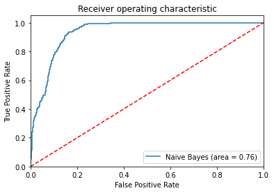

```python
# Naive-Bayes Model
from sklearn.metrics import classification_report, confusion_matrix, roc_auc_score, roc_curve, accuracy_score

NB = GaussianNB()
NB.fit(X_train, y_train)

print('Scores for NB Classifier:')
print('Train set: {0:.3f}'.format(NB.score(X_train, y_train)))
print('Test set: {0:.3f}\n'.format(NB.score(X_test, y_test)))

y_true, y_pred = y_test, NB.predict(X_test)

# Classification Report
print(classification_report(y_true, y_pred))

# Confusion Matrix
cm = confusion_matrix(y_true, y_pred)
print('Confusion Matrix:\n', cm)

# Accuracy Score
auc = accuracy_score(y_true, y_pred)
print('\nAccuracy Score:\n', auc.round(3))

# ROC Curve
NB_roc_auc = roc_auc_score(y_true, NB.predict(X_test))
fpr, tpr, thresholds = roc_curve(y_true, NB.predict_proba(X_test)[:,1])

plt.plot(fpr, tpr, label = 'Naive Bayes (area = {})'.\
         format(NB_roc_auc.round(2)))
plt.plot([0, 1], [0, 1],'r--')
plt.xlim([0.0, 1.0])
plt.ylim([0.0, 1.05])
plt.xlabel('False Positive Rate')
plt.ylabel('True Positive Rate')
plt.title('Receiver operating characteristic')
plt.legend(loc = 'lower right')
plt.show()
```

```
Logistic Regression Scores with Hyperparameter Tuning
Best Hyper Parameters are:  {'C': 10, 'max_iter': 100, 'penalty': 'l2'}
Best Score is:  0.948
Train set Accuracy: 0.949
Test set Accuracy: 0.944
              precision    recall  f1-score   support

         0.0       0.95      0.99      0.97      1343
         1.0       0.82      0.59      0.69       157

    accuracy                           0.94      1500
   macro avg       0.89      0.79      0.83      1500
weighted avg       0.94      0.94      0.94      1500


Confusion Matrix:
 [[1323   20]
 [  64   93]]

Accuracy Score:
 0.944
```

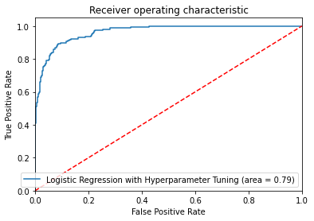

```python
# Logistic regression model
from sklearn.model_selection import train_test_split, GridSearchCV, StratifiedKFold

LR = LogisticRegression(random_state = 42)

params = {'penalty': ['l1', 'l2'], 'C': [0.001, 0.01, 0.1, 1, 10, 100], 'max_iter': [100, 110, 120, 130, 140]}

skf = StratifiedKFold(n_splits = 10)
LR_hyper = GridSearchCV(LR, param_grid = params, n_jobs = -1, cv = skf)

LR_hyper.fit(X_train, y_train)

print('Logistic Regression Scores with Hyperparameter Tuning')
print('Best Hyper Parameters are: ', LR_hyper.best_params_)
print('Best Score is: ', LR_hyper.best_score_.round(3))

print('Train set Accuracy: {0:.3f}'.format(LR_hyper.score(X_train, y_train)))
print('Test set Accuracy: {0:.3f}'.format(LR_hyper.score(X_test, y_test)))

y_true, y_pred = y_test, LR_hyper.predict(X_test)

# Classification Report
print((classification_report(y_true, y_pred)))

# Confusion Matrix
cm = confusion_matrix(y_true, y_pred)
print('\nConfusion Matrix:\n', cm)

# Accuracy Score
auc = accuracy_score(y_true, y_pred)
print('\nAccuracy Score:\n', auc.round(3))

# ROC Curve
LR_hyper_roc_auc = roc_auc_score(y_true, LR_hyper.predict(X_test))
fpr, tpr, thresholds = roc_curve(y_true, LR_hyper.predict_proba(X_test)[:,1])
plt.plot(fpr, tpr, label = 'Logistic Regression with Hyperparameter Tuning (area = {})'.\
         format(LR_hyper_roc_auc.round(2)))
plt.plot([0, 1], [0, 1],'r--')
plt.xlim([0.0, 1.0])
plt.ylim([0.0, 1.05])
plt.xlabel('False Positive Rate')
plt.ylabel('True Positive Rate')
plt.title('Receiver operating characteristic')
plt.legend(loc = 'lower right')
plt.show()
```

```
k-Nearest Neighbor Classifier Scores after Hyperparameter Tuning
Best Hyper Parameters are:  {'algorithm': 'auto', 'n_neighbors': 3, 'weights': 'distance'}

Best Score is:  0.972
k-NN accuracy for train set: 1.000
k-NN accuracy for test set: 0.968

              precision    recall  f1-score   support

         0.0       0.97      1.00      0.98      1343
         1.0       0.99      0.70      0.82       157

    accuracy                           0.97      1500
   macro avg       0.98      0.85      0.90      1500
weighted avg       0.97      0.97      0.97      1500


Confusion Matrix:
 [[1342    1]
 [  47  110]]

Accuracy Score:
 0.968
```

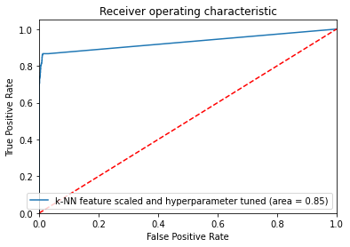

```python
# KNN with hyperparameter tuning
KNN = KNeighborsClassifier(n_jobs = -1)

params = {'n_neighbors': list(range(1, 40, 2)), 'weights': ['uniform', 'distance'],
          'algorithm': ['auto', 'ball_tree', 'kd_tree', 'brute']}

skf = StratifiedKFold(n_splits = 10)
KNN_hyper = GridSearchCV(KNN, param_grid = params, n_jobs = -1, cv = skf)

KNN_hyper.fit(X_train, y_train)

print('k-Nearest Neighbor Classifier Scores after Hyperparameter Tuning')
print('Best Hyper Parameters are: ', KNN_hyper.best_params_)
print('\nBest Score is: ', KNN_hyper.best_score_.round(3))

print('k-NN accuracy for train set: {0:.3f}'.format(KNN_hyper.score(X_train, y_train)))
print('k-NN accuracy for test set: {0:.3f}'.format(KNN_hyper.score(X_test, y_test)))

y_true, y_pred = y_test, KNN_hyper.predict(X_test)

# Classification Report
print('\n{}'.format(classification_report(y_true, y_pred)))

# Confusion Matrix
cm = confusion_matrix(y_true, y_pred)
print('\nConfusion Matrix:\n', cm)

# Accuracy Score
auc = accuracy_score(y_true, y_pred)
print('\nAccuracy Score:\n', auc.round(3))

# ROC Curve
KNN_hyper_roc_auc = roc_auc_score(y_true, KNN_hyper.predict(X_test))
fpr, tpr, thresholds = roc_curve(y_true, KNN_hyper.predict_proba(X_test)[:,1])
plt.plot(fpr, tpr, label = 'k-NN feature scaled and hyperparameter tuned (area = {})'.\
         format(KNN_hyper_roc_auc.round(2)))
plt.plot([0, 1], [0, 1],'r--')
plt.xlim([0.0, 1.0])
plt.ylim([0.0, 1.05])
plt.xlabel('False Positive Rate')
plt.ylabel('True Positive Rate')
plt.title('Receiver operating characteristic')
plt.legend(loc = 'lower right')
plt.show()
```

```python
!jupyter nbconvert --to html /content/drive/MyDrive/Nayan_Supervised_Learning_File (1).ipynb
```

[output not shown]